# EasyVisa Project

### Hyperparameter Tuning - Decision Tree

```python
#Choose the type of classifier.
dtree_estimator = DecisionTreeClassifier(class_weight={0:0.33,1:0.67},random_state=1)

# Grid of parameters to choose from
parameters = {'max_depth': np.arange(1,5),
              'min_samples_leaf': [2, 3, 5, 7],
              'max_leaf_nodes' : [2, 3, 5, 10, 20],
              'min_impurity_decrease': [0.0001,0.001,0.01]
             }

# Type of scoring used to compare parameter combinations
scorer = metrics.make_scorer(metrics.f1_score)

# Run the grid search
grid_obj = GridSearchCV(dtree_estimator, parameters, scoring=scorer,n_jobs=-1)
grid_obj = grid_obj.fit(X_train, y_train)

# Set the clf to the best combination of parameters
dtree_estimator = grid_obj.best_estimator_

# Fit the best algorithm to the data.
dtree_estimator.fit(X_train, y_train)
```

```
DecisionTreeClassifier(class_weight={0: 0.33, 1: 0.67}, max_depth=4,
                       max_leaf_nodes=10, min_impurity_decrease=0.0001,
                       min_samples_leaf=2, random_state=1)
```

```
Training performance:
    Accuracy   Recall  Precision       F1
0  0.724041 0.939562   0.727054 0.819760
Testing performance:
    Accuracy   Recall  Precision       F1
0  0.715725 0.938100   0.720584 0.815080
```

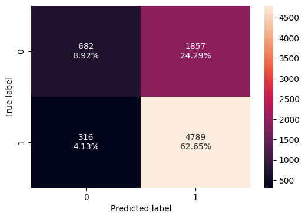

```python
#Calculating different metrics
dtree_estimator_model_train_perf=model_performance_classification_sklearn(dtree_estimator,X_train,y_train)
print("Training performance:\n",dtree_estimator_model_train_perf)

dtree_estimator_model_test_perf=model_performance_classification_sklearn(dtree_estimator,X_test,y_test)
print("Testing performance:\n",dtree_estimator_model_test_perf)

#Creating confusion matrix
confusion_matrix_sklearn(dtree_estimator, X_test, y_test)
```

#### Observations

- The hyper-tuned decision tree has approximately a .82 F1 Score for both the training and test data sets.
- The accuracy increased from .661 (from the base Decision Tree) to approximately .716 (from the hyper-tuned Decision Tree).

## Building bagging and boosting models

### Bagging Classifier

```python
#Fitting the model
bagging_classifier = BaggingClassifier(random_state=1)
bagging_classifier.fit(X_train,y_train)
```

```
BaggingClassifier(random_state=1)
```

```
Training performance:
    Accuracy   Recall  Precision       F1
0  0.983853 0.984974   0.990796 0.987877
Testing performance:
    Accuracy   Recall  Precision       F1
0  0.687991 0.761410   0.769094 0.765233
```

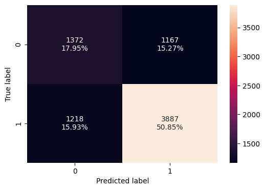

```python
#Calculating different metrics
bagging_classifier_model_train_perf=model_performance_classification_sklearn(bagging_classifier,X_train,y_train)
print("Training performance:\n",bagging_classifier_model_train_perf)

bagging_classifier_model_test_perf=model_performance_classification_sklearn(bagging_classifier,X_test,y_test)
print("Testing performance:\n",bagging_classifier_model_test_perf)

#Creating confusion matrix
confusion_matrix_sklearn(bagging_classifier, X_test, y_test)
```

#### Observations

- Bagging classifier model is overfitting training data.
- Bagging classifier model is not performing as well as the Hyper-tuned Decision Tree model.

### Hyperparameter Tuning - Bagging Classifier

```python
# Choose the type of classifier.
bagging_estimator_tuned = BaggingClassifier(random_state=1)

# Grid of parameters to choose from
parameters = {'max_samples': [0.7,0.8,0.9,1],
              'max_features': [0.7,0.8,0.9,1],
              'n_estimators' : [30,50,70],
             }

# Type of scoring used to compare parameter combinations
acc_scorer = metrics.make_scorer(metrics.f1_score)

# Run the grid search
grid_obj = GridSearchCV(bagging_estimator_tuned, parameters, scoring=acc_scorer,cv=5)
grid_obj = grid_obj.fit(X_train, y_train)

# Set the clf to the best combination of parameters
bagging_estimator_tuned = grid_obj.best_estimator_

# Fit the best algorithm to the data.
bagging_estimator_tuned.fit(X_train, y_train)
```

```
BaggingClassifier(max_features=0.7, max_samples=0.7, n_estimators=70,
                  random_state=1)
```

```
Training performance:
    Accuracy   Recall  Precision       F1
0  0.996524 0.999496   0.995319 0.997403
Testing performance:
    Accuracy   Recall  Precision       F1
0  0.727499 0.878159   0.754206 0.811476
```

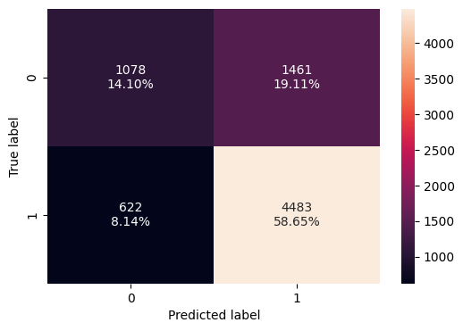

```python
#Calculating different metrics
bagging_estimator_tuned_model_train_perf=model_performance_classification_sklearn(bagging_estimator_tuned,X_train,y_train)
print("Training performance:\n",bagging_estimator_tuned_model_train_perf)

bagging_estimator_tuned_model_test_perf=model_performance_classification_sklearn(bagging_estimator_tuned,X_test,y_test)
print("Testing performance:\n",bagging_estimator_tuned_model_test_perf)

#Creating confusion matrix
confusion_matrix_sklearn(bagging_estimator_tuned, X_test, y_test)
```

### Random Forest

```python
#Fitting the model
rf_estimator = RandomForestClassifier(random_state=1)
rf_estimator.fit(X_train,y_train)
```

```
RandomForestClassifier(random_state=1)
```

```
Training performance:
    Accuracy   Recall  Precision       F1
0  1.000000 1.000000   1.000000 1.000000
Testing performance:
    Accuracy   Recall  Precision       F1
0  0.726714 0.842899   0.769767 0.804675
```

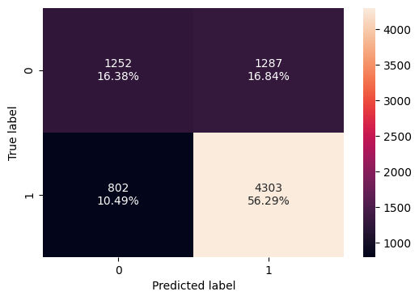

```python
#Calculating different metrics
rf_estimator_model_train_perf=model_performance_classification_sklearn(rf_estimator,X_train,y_train)
print("Training performance:\n",rf_estimator_model_train_perf)

rf_estimator_model_test_perf=model_performance_classification_sklearn(rf_estimator,X_test,y_test)
print("Testing performance:\n",rf_estimator_model_test_perf)

#Creating confusion matrix
confusion_matrix_sklearn(rf_estimator, X_test, y_test)
```

#### Observations

- The Rain Forest model is overfitting the training data.
- The Rain Forest model has a decent F1 score of approximately .805

### Hyperparameter Tuning - Random Forest

```python
# Choose the type of classifier.
rf_tuned = RandomForestClassifier(class_weight={0:0.33,1:0.67},random_state=1)

parameters = {
                "n_estimators": [50,110,25],
                "min_samples_leaf": np.arange(1, 4),
                "max_features": [np.arange(0.3, 0.6, 0.1),'sqrt'],
                "max_samples": np.arange(0.4, 0.7, 0.1)
}


# Type of scoring used to compare parameter combinations
scorer = metrics.make_scorer(metrics.f1_score)

# Run the grid search
grid_obj = GridSearchCV(rf_tuned, parameters, scoring=scorer,cv=5,n_jobs=-1)
grid_obj = grid_obj.fit(X_train, y_train)

# Set the clf to the best combination of parameters
rf_tuned = grid_obj.best_estimator_

# Fit the best algorithm to the data.
rf_tuned.fit(X_train, y_train)
```

```
RandomForestClassifier(class_weight={0: 0.33, 1: 0.67}, max_samples=0.4,
                       min_samples_leaf=3, n_estimators=110, random_state=1)
```

```
Training performance:
    Accuracy   Recall  Precision       F1
0  0.793732 0.971208   0.776198 0.862821
Testing performance:
    Accuracy   Recall  Precision       F1
0  0.727368 0.925955   0.734805 0.819379
```

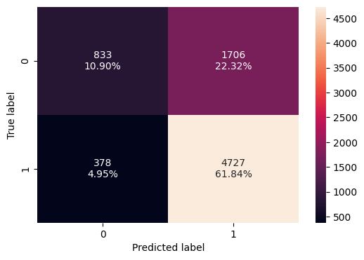

```python
#Calculating different metrics
rf_tuned_model_train_perf=model_performance_classification_sklearn(rf_tuned,X_train,y_train)
print("Training performance:\n",rf_tuned_model_train_perf)

rf_tuned_model_test_perf=model_performance_classification_sklearn(rf_tuned,X_test,y_test)
print("Testing performance:\n",rf_tuned_model_test_perf)

#Creating confusion matrix
confusion_matrix_sklearn(rf_tuned, X_test, y_test)
```

#### Observations

- The hyper-tuned Rain Forest model performed well on both the training and test data sets. It does not appear to be overfitting.
- The hyper-tuned Rain Forest model is returning an F1 score of .862 and .819 for the training and test data sets, respectively.

## Boosting - Model Building and Hyperparameter Tuning

### AdaBoost Classifier

```python
ab_classifier=AdaBoostClassifier(random_state=1)
ab_classifier.fit(X_train,y_train)

ab_classifier_model_train_perf = model_performance_classification_sklearn(ab_classifier, X_train,y_train)
print("Training performance \n",ab_classifier_model_train_perf)

ab_classifier_model_test_perf = model_performance_classification_sklearn(ab_classifier, X_test,y_test)
print("Testing performance \n",ab_classifier_model_test_perf)
```

```
Training performance
    Accuracy   Recall  Precision       F1
0  0.738114 0.887350   0.760504 0.819045
Testing performance
    Accuracy   Recall  Precision       F1
0  0.733516 0.884819   0.757124 0.816006
```

#### Observations

- The AdaBoost Classifier model is performing well and shows no signs of overfitting between the training and test data sets.
- The AdaBoost Classifier model has an approximate F1 score of .816 for both the training and test data sets.